## RStudio Exercise 5: Dimensionality reduction techniques

In this exercise we study the dimensionality reduction techniques namely, principal component analysis (PCA) and multiple correspondence analysis (MCA).

The data “human” we use in this exercise is obtained from the United Nations Development Programme. For a detailed information about the data is available [here](http://hdr.undp.org/en/content/human-development-index-hdi). The “human” dataframe has 155 observations of 8 variables. The rowname of each observation is the name of the Country associated with that observation.

The variables of the “human” dataframe

1. “GNI” = Gross National Income per capita
2. “Life.Exp” = Life expectancy at birth
3. “Edu.Exp” = Expected years of schooling
4. “Mat.Mor” = Maternal mortality ratio
5. “Ado.Birth” = Adolescent birth rate
6. “Parli.F” = Percetange of female representatives in parliament
7. “Edu2.FM” = Edu2.F / Edu2.M
8. “Labo.FM” = Labo2.F / Labo2.M

“Edu2.F” and “Edu2.M” are the proportion of females and males with at least secondary education. Edu2.FM is a derived variable which is the ratio of females with secondary education(Edu2.F) to males with secondary education(Edu2.M). So Edu2.FM = Edu2.F/Edu2.M.

“Labo.M”and “Labo.F” are the proportion of females and males in the labour force. “Labo.FM” is the ratio of Labo2.F / Labo2.M.

Note: “Edu2.F” and “Edu2.M” and “Labo.F” and “Labo.M”" were in the original UNDP dataset available at http://hdr.undp.org/en/content/human-development-index-hdi.

### 1. Load the “human” data into R

I have the “human.csv” file is also in my github data directory https://github.com/ldaniel2016/IODS-project/blob/master/data/human.csv In this program, I am using the names given by Tuomo Nieminen, I download the “human”" data available at amazon aws.

```r
human <- read.table("http://s3.amazonaws.com/assets.datacamp.com/production/course_2218/datasets/human2.txt", sep = ",", header = TRUE)

str(human)
```

```
## 'data.frame':    155 obs. of  8 variables:
##  $ Edu2.FM  : num  1.007 0.997 0.983 0.989 0.969 ...
##  $ Labo.FM  : num  0.891 0.819 0.825 0.884 0.829 ...
##  $ Edu.Exp  : num  17.5 20.2 15.8 18.7 17.9 16.5 18.6 16.5 15.9 19.2 ...
##  $ Life.Exp : num  81.6 82.4 83 80.2 81.6 80.9 80.9 79.1 82 81.8 ...
##  $ GNI      : int  64992 42261 56431 44025 45435 43919 39568 52947 42155 32689 ...
##  $ Mat.Mor  : int  4 6 6 5 6 7 9 28 11 8 ...
##  $ Ado.Birth: num  7.8 12.1 1.9 5.1 6.2 3.8 8.2 31 14.5 25.3 ...
##  $ Parli.F  : num  39.6 30.5 28.5 38 36.9 36.9 19.9 19.4 28.2 31.4 ...
```

### 2. Graphical overview and summaries of “human” dataframe

#### Summary of the variables

The summary of the human data gives the quartiles, minimum and maximum values of the variables in the human dataset.

```r
summary(human)
```

```
##     Edu2.FM          Labo.FM          Edu.Exp         Life.Exp
##  Min.   :0.1717   Min.   :0.1857   Min.   : 5.40   Min.   :49.00
##  1st Qu.:0.7264   1st Qu.:0.5984   1st Qu.:11.25   1st Qu.:66.30
##  Median :0.9375   Median :0.7535   Median :13.50   Median :74.20
##  Mean   :0.8529   Mean   :0.7074   Mean   :13.18   Mean   :71.65
##  3rd Qu.:0.9968   3rd Qu.:0.8535   3rd Qu.:15.20   3rd Qu.:77.25
##  Max.   :1.4967   Max.   :1.0380   Max.   :20.20   Max.   :83.50
##       GNI            Mat.Mor         Ado.Birth         Parli.F
##  Min.   :   581   Min.   :   1.0   Min.   :  0.60   Min.   : 0.00
##  1st Qu.:  4198   1st Qu.:  11.5   1st Qu.: 12.65   1st Qu.:12.40
##  Median : 12040   Median :  49.0   Median : 33.60   Median :19.30
##  Mean   : 17628   Mean   : 149.1   Mean   : 47.16   Mean   :20.91
##  3rd Qu.: 24512   3rd Qu.: 190.0   3rd Qu.: 71.95   3rd Qu.:27.95
##  Max.   :123124   Max.   :1100.0   Max.   :204.80   Max.   :57.50
```

#### Correlation between the variables

We use the correlation between the variables of the data. We create a corr_matrix by using the cor() function on human data. To visualize the correlation we use the corr_plot function from the corr_plot package. As the correlation matrix is symmetric we need only upper or lower matrix. Here we get the correlation as numbers.

We can see that there is a high correlation of GNI with life expectancy and expected level of schooling. Also Maternal mortality and adolescent birth rates are strongly correlated.

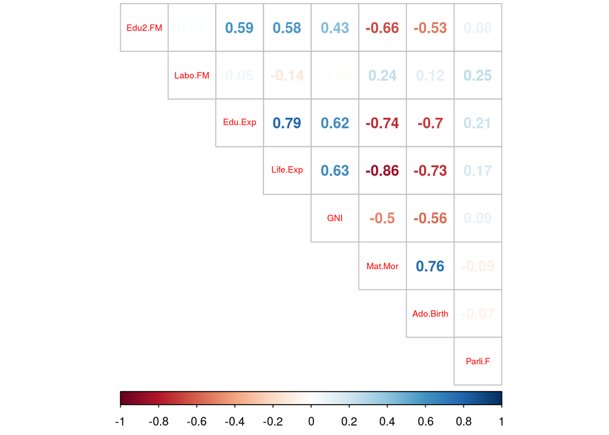

```r
library(corrplot); library(dplyr)
cor_matrix<-cor(human) %>% round(digits=2)

# visualize the correlation matrix
corrplot(cor_matrix, method="number", type = "upper", cl.pos = "b", tl.pos = "d", tl.cex = 0.6)
```

#### Scatter plots and distributions

Here is another way of showing the distributions of the variables and the correlation between pairs using the ggpairs function. From the scatter plots of the variables we can see that Edu.FM, the ratio of secondary school education for women and men is highly skewed. The Edu.Exp, the expected years of schooling is a normal variable with a mean of 13 yrs.

It is very interesting to see that GNI is a very skewed variable, there is a high variation in the “wealth” of nations.

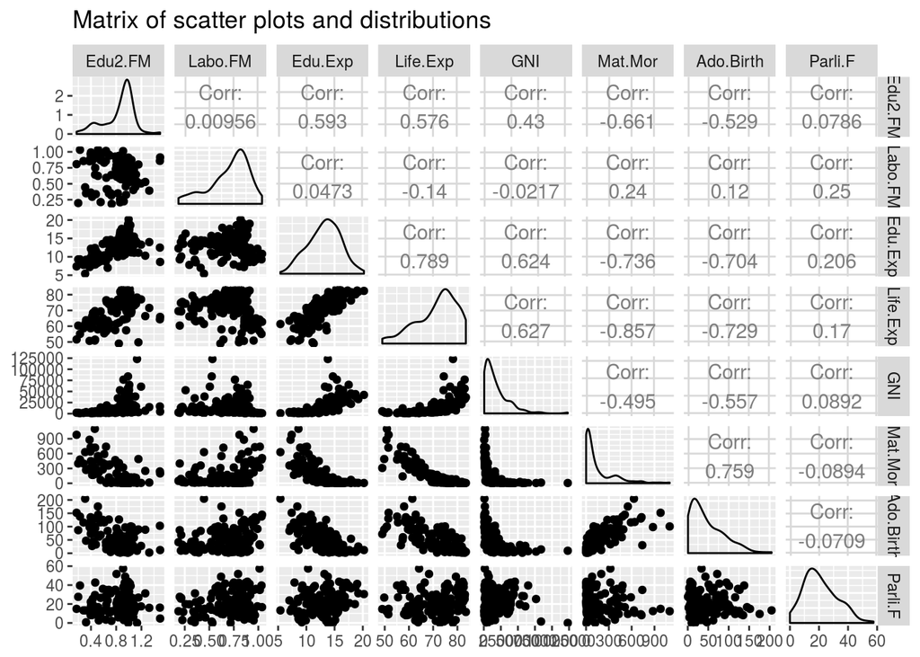

```r
library (ggplot2)
library (GGally)
ggpairs(human, mapping = aes(), lower = list(combo = wrap("facethist", bins = 20))) + ggtitle("Matrix of scatter plots and distributions")
```

### 3. Principal Component Analysis (PCA) on ono_standardized “human” data

Principal Component Analysis (PCA) is a statistical procedure that uses an orthogonal transformation to convert a set of observations of possibly correlated variables into a set of values of linearly uncorrelated variables called principal components (Wikipedia). PCA transforms the data in terms of the eigenvalues and eigenvectors of the data. In other words, we can define PCA as a statistical procedure on a data set with large number of variables that yields a smaller number of uncorrelated variables called principal components with which we can explain the maximum amount of variance in the data. The first component explains the highest variance, followed by the second and so on. The dimension of the data is the number of variables or attributes associated with the data. The number of uncorrelated (orthogonal) components are less than or equal to the number of original variables. So PCA “approximates” the behaviour of the data with fewer principal components so it is a dimensionality reduction technique.

For PCA, I use the prcomp function available in R. The prcomp() function uses the SVD (singular value decomposition) which gives a more numerically accurate method. SVD decomposes a data matrix into a product of smaller matrices, and then extract the underlying principal components.

#### PCA on non_standardized human data with svd method.

First we do the pca on the human data which is not standardized. So the range of values of the observations vary widely. For example, in the case of Norway, the GNI variable has a value 64992 whereas Edu2.FM is 1.007.

pca_human_not_std$rotation gives the matrix of variable loading. The columns of the matrix are the PCs (eigenvectors) and how each variable is composed of these principal components. We can see from this matrix that GNI has the highest component of PC1. This is because GNI is about 10000 times larger than the other variables. Not standardizing the variables results in a very “strong” first principal component which contributes about 100 % to the variance and the contribution of the rest of the components almost nil. The result clearly shows that we need to standardize the variables before doing PCA.

```r
# Perform PCA using prcomp
pca_human_not_std <- prcomp(human)
```

##### Summary of pca_human_not_std

```r
summary(pca_human_not_std)
```

```
## Importance of components:
##                              PC1      PC2   PC3   PC4   PC5   PC6    PC7
## Standard deviation     1.854e+04 185.5219 25.19 11.45 3.766 1.566 0.1912
## Proportion of Variance 9.999e-01   0.0001  0.00  0.00 0.000 0.000 0.0000
## Cumulative Proportion  9.999e-01   1.0000  1.00  1.00 1.000 1.000 1.0000
##                           PC8
## Standard deviation     0.1591
## Proportion of Variance 0.0000
## Cumulative Proportion  1.0000
```

```r
pca_human_not_std$rotation
```

```
##                     PC1           PC2           PC3           PC4
## Edu2.FM   -5.607472e-06  0.0006713951 -3.412027e-05 -2.736326e-04
## Labo.FM    2.331945e-07 -0.0002819357  5.302884e-04 -4.692578e-03
## Edu.Exp   -9.562910e-05  0.0075529759  1.427664e-02 -3.313505e-02
## Life.Exp  -2.815823e-04  0.0283150248  1.294971e-02 -6.752684e-02
## GNI       -9.999832e-01 -0.0057723054 -5.156742e-04  4.932889e-05
## Mat.Mor    5.655734e-03 -0.9916320120  1.260302e-01 -6.100534e-03
## Ado.Birth  1.233961e-03 -0.1255502723 -9.918113e-01  5.301595e-03
## Parli.F   -5.526460e-05  0.0032317269 -7.398331e-03 -9.971232e-01
##                     PC5           PC6           PC7           PC8
## Edu2.FM   -0.0022935252  2.180183e-02  6.998623e-01  7.139410e-01
## Labo.FM    0.0022190154  3.264423e-02  7.132267e-01 -7.001533e-01
## Edu.Exp    0.1431180282  9.882477e-01 -3.826887e-02  7.776451e-03
## Life.Exp   0.9865644425 -1.453515e-01  5.380452e-03  2.281723e-03
## GNI       -0.0001135863 -2.711698e-05 -8.075191e-07 -1.176762e-06
## Mat.Mor    0.0266373214  1.695203e-03  1.355518e-04  8.371934e-04
## Ado.Birth  0.0188618600  1.273198e-02 -8.641234e-05 -1.707885e-04
## Parli.F   -0.0716401914 -2.309896e-02 -2.642548e-03  2.680113e-03
```

##### Biplot of pca_human_not_std

A biplot visualizes the connection between two representations of the same data. First a simple scatter plot is drawn which shows the observations represented by two highest valued principal components (PC1 and PC2). Then arrows are drawn to give the connection between the variables of the data and the PCs. The angle between the variables can be interpreted as the correlation between the variables. The angle between the a variable and a PC axis can be interpreted as the correlation between them. The length of the arrows are proportional to the standard deviation of the variables.

The biplot of pca_human_not_std show that GNI has high negative correlation along the PC1 direction.

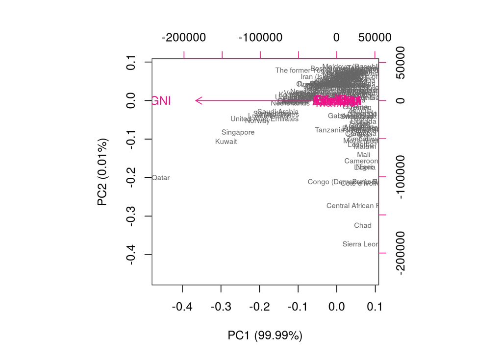

```r
s <- summary(pca_human_not_std)
# rounded percetanges of variance captured by each PC
pca_pr <- round(100*s$importance[2, ], digits = 2)
# create object pc_lab to be used as axis labels
pc_lab <- paste0(names(pca_pr), " (", pca_pr, "%)")
biplot(pca_human_not_std, choices = 1:2, cex = c(0.6,1), col = c("grey40", "deeppink2"), xlab = pc_lab[1], ylab = pc_lab[2])
```

### 4. PCA on standardized “human”" data with svd method

We standardize the variables of “human” data by subtracting the mean from each column and dividing the difference with standard deviation. This can be achieved in R by the scale() function.

We can see from the importance of components that PC1 contributes to 53.6 % of the variance, PC2 contributes 16 % of the variance and the PC3 to PC8 contribute the rest about 30 % of the variance.

pca_human_std$rotation gives the matrix of variable loading. The columns of the matrix are the PCs (eigenvectors) and how each variable is composed of these principal components.

pca_human_std$x gives each observations in terms of the PCA components For example, To the country, Norway, how much PC1 to PC8 are contributing to the variance.

```r
# We standardize the human data
human_std <- scale(human)

# Perform PCA with prcomp
pca_human_std <- prcomp(human_std)
```

##### Summary of pca_human_std

```r
summary(pca_human_std)
```

```
## Importance of components:
##                           PC1    PC2     PC3     PC4     PC5     PC6
## Standard deviation     2.0708 1.1397 0.87505 0.77886 0.66196 0.53631
## Proportion of Variance 0.5361 0.1624 0.09571 0.07583 0.05477 0.03595
## Cumulative Proportion  0.5361 0.6984 0.79413 0.86996 0.92473 0.96069
##                            PC7     PC8
## Standard deviation     0.45900 0.32224
## Proportion of Variance 0.02634 0.01298
## Cumulative Proportion  0.98702 1.00000
```

```r
pca_human_std$rotation
```

```
##                   PC1         PC2         PC3         PC4        PC5
## Edu2.FM   -0.35664370  0.03796058 -0.24223089  0.62678110 -0.5983585
## Labo.FM    0.05457785  0.72432726 -0.58428770  0.06199424  0.2625067
## Edu.Exp   -0.42766720  0.13940571 -0.07340270 -0.07020294  0.1659678
## Life.Exp  -0.44372240 -0.02530473  0.10991305 -0.05834819  0.1628935
## GNI       -0.35048295  0.05060876 -0.20168779 -0.72727675 -0.4950306
## Mat.Mor    0.43697098  0.14508727 -0.12522539 -0.25170614 -0.1800657
## Ado.Birth  0.41126010  0.07708468  0.01968243  0.04986763 -0.4672068
## Parli.F   -0.08438558  0.65136866  0.72506309  0.01396293 -0.1523699
##                   PC6         PC7         PC8
## Edu2.FM    0.17713316  0.05773644  0.16459453
## Labo.FM   -0.03500707 -0.22729927 -0.07304568
## Edu.Exp   -0.38606919  0.77962966 -0.05415984
## Life.Exp  -0.42242796 -0.43406432  0.62737008
## GNI        0.11120305 -0.13711838 -0.16961173
## Mat.Mor    0.17370039  0.35380306  0.72193946
## Ado.Birth -0.76056557 -0.06897064 -0.14335186
## Parli.F    0.13749772  0.00568387 -0.02306476
```

```r
head(pca_human_std$x)
```

```
##                   PC1      PC2         PC3        PC4         PC5
## Norway      -3.083783 1.890282  0.05696973 -1.4290857 -0.63459195
## Australia   -2.993702 1.188202 -0.10676531 -0.6675752  0.14660317
## Switzerland -2.696833 0.896900 -0.27504818 -1.1663781 -0.29331001
## Denmark     -2.781202 1.773430  0.17130228 -0.6834719  0.05608187
## Netherlands -2.727161 1.469105  0.30813082 -0.7979935 -0.02447366
## Germany     -2.513256 1.320373  0.38889822 -0.6482659 -0.14005450
##                    PC6         PC7         PC8
## Norway       0.1057068 -0.02143594 -0.12382024
## Australia   -0.6199684  0.91743878  0.12226133
## Switzerland  0.1865274 -0.42048569  0.14993123
## Denmark     -0.0930002  0.54465202 -0.05449691
## Netherlands -0.0840486  0.29968327  0.06210630
## Germany      0.1990240 -0.00111454  0.08575525
```

##### Biplot of pca_human_std

The bipolar plot shows the correlations between the variables and the principal components. We can observe from the biplot that Edu2.FM (Ratio of secondary level education of females to males), Edu.Exp (Expected years of schooling), Life.Exp (life expectancy at birth ), GNI (Gross National Income per capita) are highly correlated variables and they are along the negative PC1 axis.  
Mat.Mor (Maternal mortality ratio), Ado.Birth (Adolescent birth rate) are also highly correlated variables that lie in the positive direction of PC1.

Labo.FM (labour force participation ratio of females to males) and Parli.F (Percetange of female representatives in parliament) have high PC2 components than PC1. They are quite orthogonal to PC1.

The plot also shows the observations (rownames of the observations are the name of the Countries) represented by two highest valued principal components (PC1 and PC2).

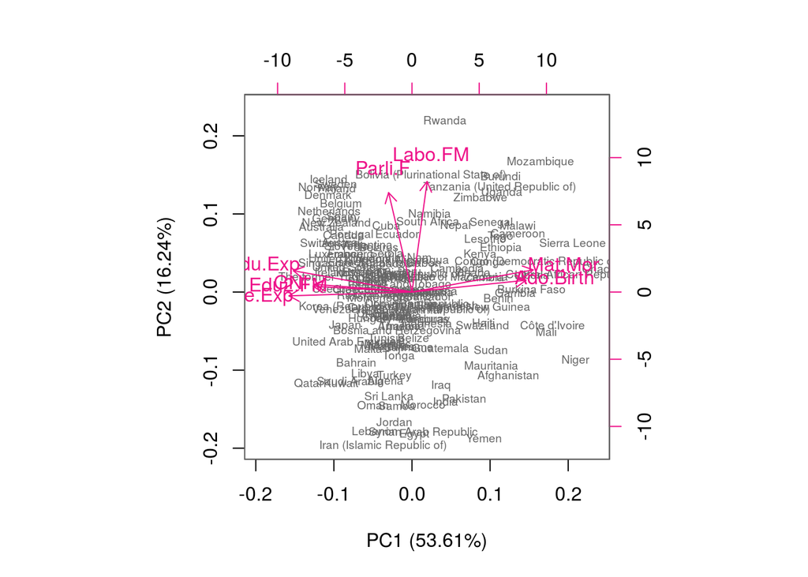

```r
s <- summary(pca_human_std)
# rounded percetanges of variance captured by each PC
pca_pr <- round(100*s$importance[2, ], digits = 2)
# create object pc_lab to be used as axis labels
pc_lab <- paste0(names(pca_pr), " (", pca_pr, "%)")
biplot(pca_human_std, choices = 1:2, cex = c(0.6,1), col = c("grey40", "deeppink2"), xlab = pc_lab[1], ylab = pc_lab[2])
```

##### Circle of correlations

We can have a separate plot of correlations of the variables and PC1 and PC2. This gives the same visualization as biplot without the observations.

Here we show a plot of the correlations of the variables with PC1 and PC2.

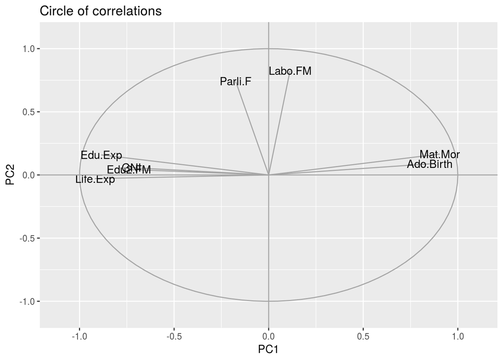

```r
# function to create a circle
circle <- function(center = c(0, 0), npoints = 100) {
    r = 1
    tt = seq(0, 2 * pi, length = npoints)
    xx = center[1] + r * cos(tt)
    yy = center[1] + r * sin(tt)
    return(data.frame(x = xx, y = yy))
}
corcir = circle(c(0, 0), npoints = 100)

# create data frame with correlations between variables and PCs
correlations = as.data.frame(cor(human_std, pca_human_std$x))

# data frame with arrows coordinates
arrows = data.frame(x1 = c(0, 0, 0, 0), y1 = c(0, 0, 0, 0), x2 = correlations$PC1,
    y2 = correlations$PC2)

# geom_path will do open circles
ggplot() + geom_path(data = corcir, aes(x = x, y = y), colour = "gray65") +
    geom_segment(data = arrows, aes(x = x1, y = y1, xend = x2, yend = y2), colour = "gray65") +
    geom_text(data = correlations, aes(x = PC1, y = PC2, label = rownames(correlations))) +
    geom_hline(yintercept = 0, colour = "gray65") + geom_vline(xintercept = 0,
    colour = "gray65") + xlim(-1.1, 1.1) + ylim(-1.1, 1.1) + labs(x = "PC1",
    y = "PC2") + ggtitle("Circle of correlations")
```

##### Plot of Countries (observations) vs Principal Components PC1 and PC2

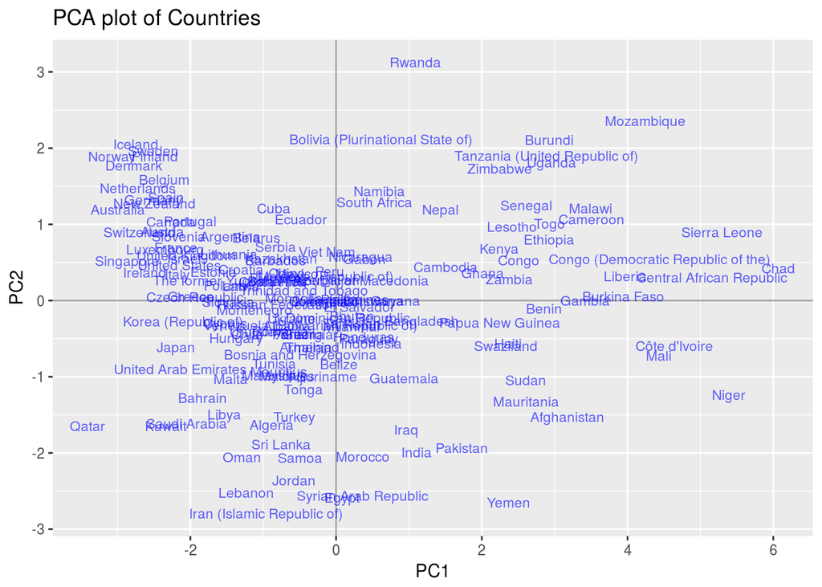

```r
library(ggplot2)
scores = as.data.frame(pca_human_std$x)

# plot of observations
ggplot(data = scores, aes(x = PC1, y = PC2, label = rownames(scores))) +
  geom_hline(yintercept = 0, colour = "gray65") +
  geom_vline(xintercept = 0, colour = "gray65") +
  geom_text(colour = "blue", alpha = 0.6, size = 3) +
  ggtitle("PCA plot of Countries")
```

### 5. Analysis results on PCA on “human” data

With the Human Development index (HDI) and Gender Inequality Index (GII) data we created the “human” data. We selected the variables Edu2.FM (Ratio of secondary level education of females to males), Labo.FM (Ratio of labour force participation of females to males), Edu.Exp(Expected years of schooling), Life.Exp (Life expectancy at birth), GNI(Gross National Income per capita), Mat.Mor(Maternal mortality rate), Ado.Birth(Adolescent birth rate), Parli.F (Percetange of female representatives in parliament).

We analysed the summary of the PCA analysis on standardized human data and we plotted many graphs to highlight the correlation between variables and the two principal components PC1 and PC2.

PC1 has high negative correlation with Edu.Exp, Edu.FM, Life.Exp and GNI. PC1 has high positive correlation with Mat.Mor and Ado.Birth. Parli.F and Labo.FM are almost orthogonal to PC1 and and they have high correlation with PC2. PC1 explains 53.6 % of the variance whereas PC2 explains 16.2 % variance. So together they explain about 70 % of the variance.

We can observe that in the case of the “Scandinavian”" countries (Norway, Finland, Sweden and Denmark), even though their GNI differ, they enjoy a high HDI rank as the education system in these countries are quite good, they give equal opportunities to women and men and also good health facilities are provided for the citizens.

In my opinion, a lot of improvement in HDI can be obtained if the “World” gives importance to education, health and gender equality.

### 6. Multiple correspondence analysis (MCA) anlaysis on tea dataset

Multiple correspondence analysis (MCA) is an extension of correspondence analysis (CA) which allows one to analyze the pattern of relationships of several categorical dependent variables. It can be seen as a generalization of principal component analysis (PCA) when the variables to be analyzed are categorical instead of quantitative (continuous).

The tea data set from FactoMineR has 300 observations on 36 variables. The dataset contains the answers of a questionnaire on tea consumption.

Here is a good video from one of the authors of FactoMineR package [MCA](https://www.youtube.com/watch?v=reG8Y9ZgcaQ)

#### Loading the tea dataset

```r
library(FactoMineR)
library(dplyr)
library(tidyr)
data(tea)
str(tea)
```

```
## 'data.frame':    300 obs. of  36 variables:
##  $ breakfast       : Factor w/ 2 levels "breakfast","Not.breakfast": 1 1 2 2 1 2 1 2 1 1 ...
##  $ tea.time        : Factor w/ 2 levels "Not.tea time",..: 1 1 2 1 1 1 2 2 2 1 ...
##  $ evening         : Factor w/ 2 levels "evening","Not.evening": 2 2 1 2 1 2 2 1 2 1 ...
##  $ lunch           : Factor w/ 2 levels "lunch","Not.lunch": 2 2 2 2 2 2 2 2 2 2 ...
##  $ dinner          : Factor w/ 2 levels "dinner","Not.dinner": 2 2 1 1 2 1 2 2 2 2 ...
##  $ always          : Factor w/ 2 levels "always","Not.always": 2 2 2 2 1 2 2 2 2 2 ...
##  $ home            : Factor w/ 2 levels "home","Not.home": 1 1 1 1 1 1 1 1 1 1 ...
##  $ work            : Factor w/ 2 levels "Not.work","work": 1 1 2 1 1 1 1 1 1 1 ...
##  $ tearoom         : Factor w/ 2 levels "Not.tearoom",..: 1 1 1 1 1 1 1 1 1 2 ...
##  $ friends         : Factor w/ 2 levels "friends","Not.friends": 2 2 1 2 2 2 1 2 2 2 ...
##  $ resto           : Factor w/ 2 levels "Not.resto","resto": 1 1 2 1 1 1 1 1 1 1 ...
##  $ pub             : Factor w/ 2 levels "Not.pub","pub": 1 1 1 1 1 1 1 1 1 1 ...
##  $ Tea             : Factor w/ 3 levels "black","Earl Grey",..: 1 1 2 2 2 2 2 1 2 1 ...
##  $ How             : Factor w/ 4 levels "alone","lemon",..: 1 3 1 1 1 1 1 3 3 1 ...
```

[output cut: 22 more lines]

#### Active variables, quantitative variables and qualilative supplementary variables of tea dataset

The tea data set has 300 observations of 36 variables. The first 18 variables are active variables and they are categorical variables. So the dimensions of MCA will be restricted to this first 18 variables. The rest of the variables are used to understand and interpret the dimensions.

The only quantitative(continuous) variable is variable 19, “age” and the variables 20:36 are qualitative supplementary categorical variables.

```r
colnames(tea)
```

```
##  [1] "breakfast"        "tea.time"         "evening"
##  [4] "lunch"            "dinner"           "always"
##  [7] "home"             "work"             "tearoom"
## [10] "friends"          "resto"            "pub"
## [13] "Tea"              "How"              "sugar"
## [16] "how"              "where"            "price"
## [19] "age"              "sex"              "SPC"
## [22] "Sport"            "age_Q"            "frequency"
## [25] "escape.exoticism" "spirituality"     "healthy"
## [28] "diuretic"         "friendliness"     "iron.absorption"
## [31] "feminine"         "sophisticated"    "slimming"
## [34] "exciting"         "relaxing"         "effect.on.health"
```

```r
summary(tea)
```

```
##          breakfast           tea.time          evening          lunch
##  breakfast    :144   Not.tea time:131   evening    :103   lunch    : 44
##  Not.breakfast:156   tea time    :169   Not.evening:197   Not.lunch:256
##
##
##
##
##
##         dinner           always          home           work
##  dinner    : 21   always    :103   home    :291   Not.work:213
##  Not.dinner:279   Not.always:197   Not.home:  9   work    : 87
##
##
##
##
##
##         tearoom           friends          resto          pub
##  Not.tearoom:242   friends    :196   Not.resto:221   Not.pub:237
##  tearoom    : 58   Not.friends:104   resto    : 79   pub    : 63
##
##
##
##
##
##         Tea         How           sugar                     how
##  black    : 74   alone:195   No.sugar:155   tea bag           :170
##  Earl Grey:193   lemon: 33   sugar   :145   tea bag+unpackaged: 94
##  green    : 33   milk : 63                  unpackaged        : 36
##                  other:  9
##
##
##
##                   where                 price          age        sex
##  chain store         :192   p_branded      : 95   Min.   :15.00   F:178
##  chain store+tea shop: 78   p_cheap        :  7   1st Qu.:23.00   M:122
##  tea shop            : 30   p_private label: 21   Median :32.00
##                             p_unknown      : 12   Mean   :37.05
##                             p_upscale      : 53   3rd Qu.:48.00
##                             p_variable     :112   Max.   :90.00
##
```

[output cut: 25 more lines]

```
##  feminine    :129   Not.sophisticated: 85   No.slimming:255
##  Not.feminine:171   sophisticated    :215   slimming   : 45
##
##
##
##
##
##         exciting          relaxing              effect.on.health
##  exciting   :116   No.relaxing:113   effect on health   : 66
##  No.exciting:184   relaxing   :187   No.effect on health:234
##
##
##
##
##
```

#### Visualization of “tea” dataset

The plot of tea data set shows different categorical variables and the count (of answers) for each category. The count will be clearly seen if get the plot in a new window.

One of the active variable is “Tea” which has three categories namely, black, Earl Grey and green. Another active variable is “How”, how the tea is used with the categories “alone”, with “lemon”, with “milk” or with “other”.

[figure not shown]

```r
gather(tea) %>% ggplot(aes(value)) + facet_wrap("key", scales = "free") +geom_bar() + theme(axis.text.x = element_text(angle = 45, hjust = 1, size = 8))
```

#### MCA on tea dataset

The tea data set has 36 variables. The active variables are the first 1:18 variables. We can specify the MCA command the quantitative and the qualitative supplementary variables. We use the MCA function from FactoMineR package for the multiple correspondence analysis.

The summary gives the eigenvalues, the percentage of variance explained by each dimension and the cumulative % of variance. We can see that the first dimension explains 9.8 % of the variance, the second dimension 8 % and so on with decreasing percentage of contributions from the rest of the dimensions.

Then we can see the first 10 individuals, the coordinate of the individual on first dimension, its contribution to the first dimension and then we have cos², which represents the quality of the individual on that dimension. If the cos² value is near 1, the individual is well projected on that dimension. We can see similar values for the dimension 2 and 3.

Next we have the results for the categories, first the active categorical variables. The summary also shows the influence of the categorical variable on dimensions which measures the square of correlation ratio. If this value is close to 1, there is a strong correlation between the categorical variable and the dimension. Similar results for supplementary categorical and continuous variable for different dimensions. We have only one continuous variable age and it contributes 0.2 to the dimension 2.

In the MCA call if we set graph is TRUE we get four graphs (pl click on the graphs). The first is the factor map of the categories with Dim1 (dimension 1) and Dim 2. The second graph shows how the individuals are distributed with the two dimensions. The third graph shows how the variables, active in red, qualitative supplementary variables in green and quantitative variable “age” in blue are distributed with the two dimensions. We can see that the variable “where” has a high contribution from Dim1 and Dim2. The fourth graph is a correlation circle which shows the “age” variable with a small correlation (0.204) along the dimension 2.

The coordinates for a variable shown in the graph is the squared correlation ratio between the dimension and the categorical/continuous variable.

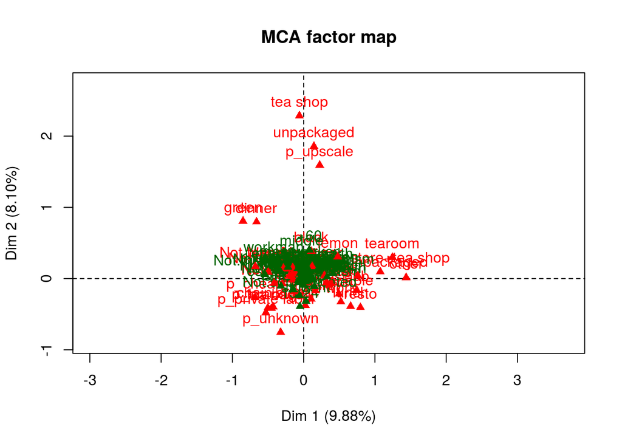

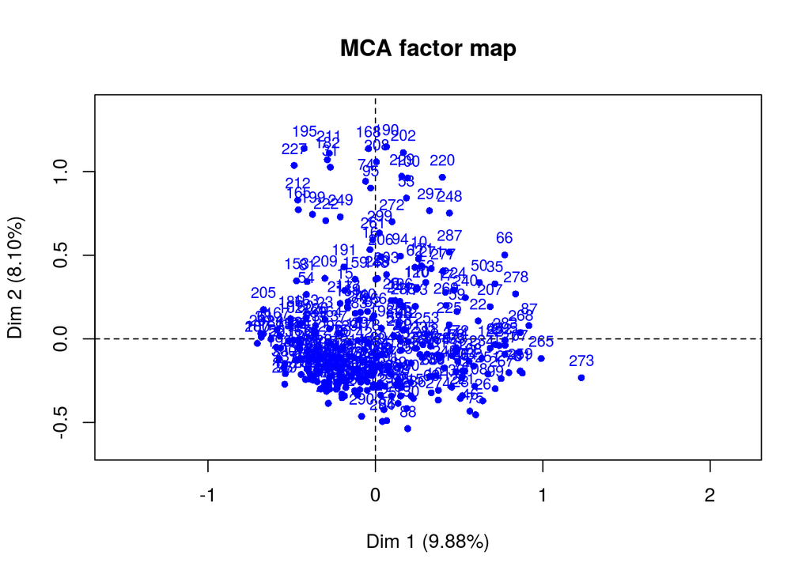

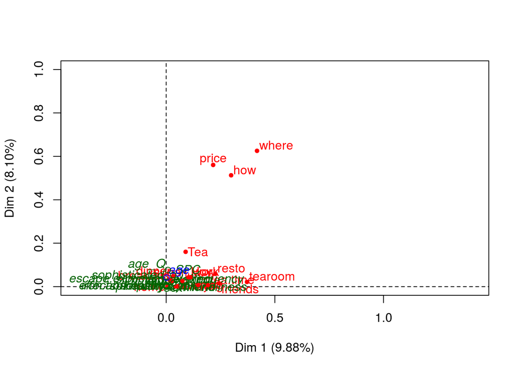

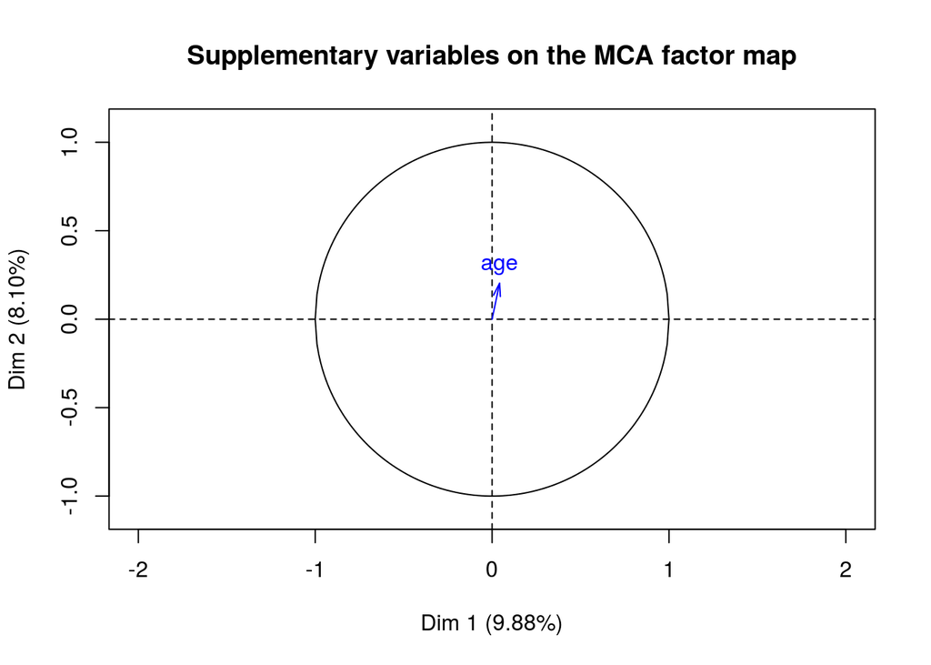

```r
mca <- MCA(tea, quanti.sup = 19, quali.sup = 20:36, graph = TRUE )
```

```r
summary(mca)
```

```
##
## Call:
## MCA(X = tea, quanti.sup = 19, quali.sup = 20:36, graph = TRUE)
##
##
## Eigenvalues
##                        Dim.1   Dim.2   Dim.3   Dim.4   Dim.5   Dim.6
## Variance               0.148   0.122   0.090   0.078   0.074   0.071
## % of var.              9.885   8.103   6.001   5.204   4.917   4.759
## Cumulative % of var.   9.885  17.988  23.989  29.192  34.109  38.868
##                        Dim.7   Dim.8   Dim.9  Dim.10  Dim.11  Dim.12
## Variance               0.068   0.065   0.062   0.059   0.057   0.054
## % of var.              4.522   4.355   4.123   3.902   3.805   3.628
## Cumulative % of var.  43.390  47.745  51.867  55.769  59.574  63.202
##                       Dim.13  Dim.14  Dim.15  Dim.16  Dim.17  Dim.18
## Variance               0.052   0.049   0.048   0.047   0.046   0.040
## % of var.              3.462   3.250   3.221   3.127   3.037   2.683
## Cumulative % of var.  66.664  69.914  73.135  76.262  79.298  81.982
##                       Dim.19  Dim.20  Dim.21  Dim.22  Dim.23  Dim.24
## Variance               0.038   0.037   0.036   0.035   0.031   0.029
## % of var.              2.541   2.438   2.378   2.323   2.055   1.915
## Cumulative % of var.  84.523  86.961  89.339  91.662  93.717  95.633
##                       Dim.25  Dim.26  Dim.27
## Variance               0.027   0.021   0.017
## % of var.              1.821   1.407   1.139
## Cumulative % of var.  97.454  98.861 100.000
##
## Individuals (the 10 first)
##                  Dim.1    ctr   cos2    Dim.2    ctr   cos2    Dim.3
## 1             | -0.541  0.658  0.143 | -0.149  0.061  0.011 | -0.306
## 2             | -0.361  0.293  0.133 | -0.078  0.017  0.006 | -0.633
## 3             |  0.073  0.012  0.003 | -0.169  0.079  0.018 |  0.246
## 4             | -0.572  0.735  0.235 |  0.018  0.001  0.000 |  0.203
## 5             | -0.253  0.144  0.079 | -0.118  0.038  0.017 |  0.006
## 6             | -0.684  1.053  0.231 |  0.032  0.003  0.001 | -0.018
## 7             | -0.111  0.027  0.022 | -0.182  0.090  0.059 | -0.207
## 8             | -0.210  0.099  0.043 | -0.068  0.013  0.004 | -0.421
## 9             |  0.118  0.031  0.012 |  0.229  0.144  0.044 | -0.538
## 10            |  0.258  0.150  0.045 |  0.478  0.627  0.156 | -0.482
##                  ctr   cos2
```

[output cut: 73 more lines]

```
##                    Dim.1 Dim.2 Dim.3
## sex              | 0.033 0.017 0.003 |
## SPC              | 0.032 0.053 0.076 |
## Sport            | 0.001 0.000 0.002 |
## age_Q            | 0.008 0.077 0.146 |
## frequency        | 0.094 0.006 0.064 |
## escape.exoticism | 0.000 0.007 0.000 |
## spirituality     | 0.005 0.000 0.016 |
## healthy          | 0.000 0.000 0.008 |
## diuretic         | 0.004 0.000 0.013 |
## friendliness     | 0.071 0.001 0.013 |
##
## Supplementary continuous variable
##                  Dim.1    Dim.2    Dim.3
## age           |  0.042 |  0.204 | -0.340 |
```

#### Plotting mca

##### MCA plot with only active categories

Here we plot the active categories, selecting the 20 most contributed ones. The unselected are shown in gray.

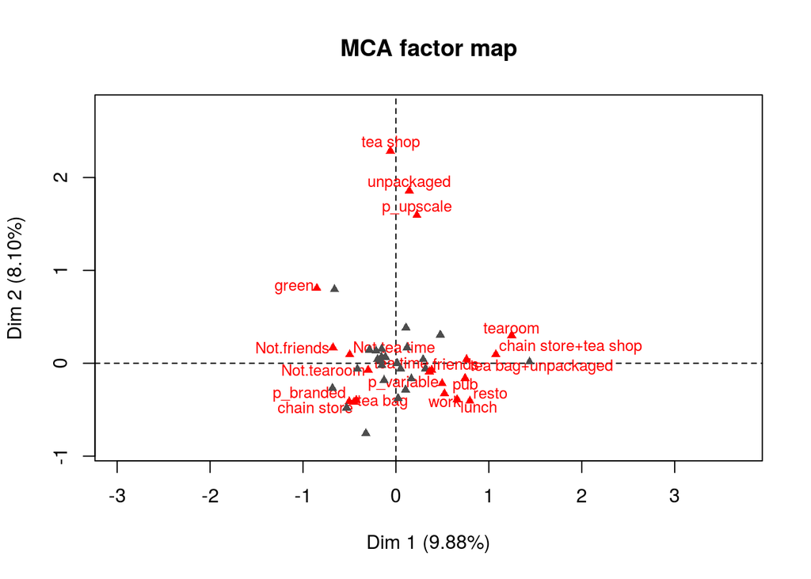

```r
plot(mca, invisible = c("ind", "quali.sup"),cex = 0.8, selectMod="contrib 20", unselect = "gray 30")
```

##### MCA plot with only the categories of the qualitative supplementary variables

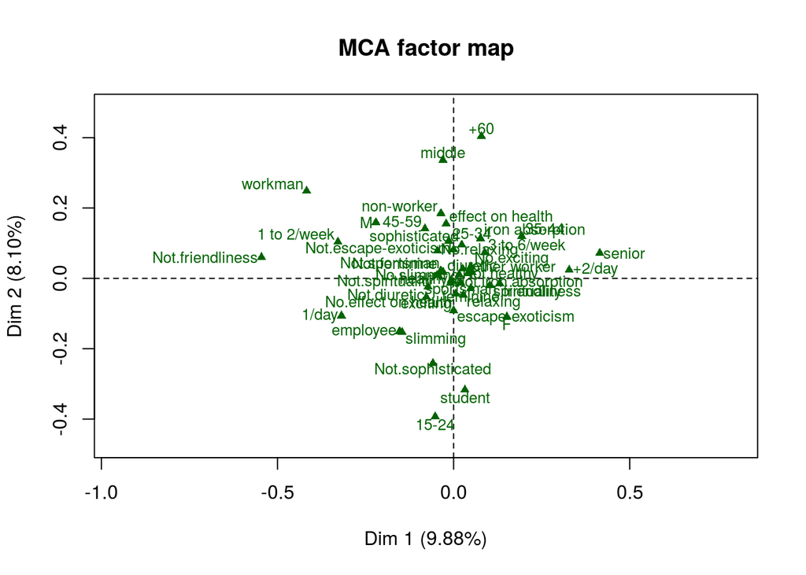

```r
plot(mca, invisible = c("var","ind"),cex = 0.8)
```

##### MCA plot with only the active categories and individuals

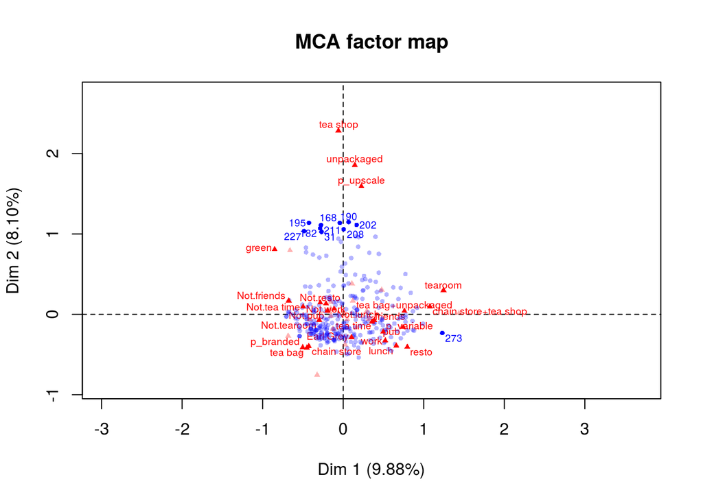

```r
plot(mca, invisible = c("quali.sup"),cex = 0.6, selectMod = "cos2 0.1", select="contrib 10")
```

##### MCA plot with different colour for individual’s tea habits.

The plot shows in individuals who drink tea once per day, one to two times per week and so on. We can see that there are more green dots which shows many people drink tea two times a day.

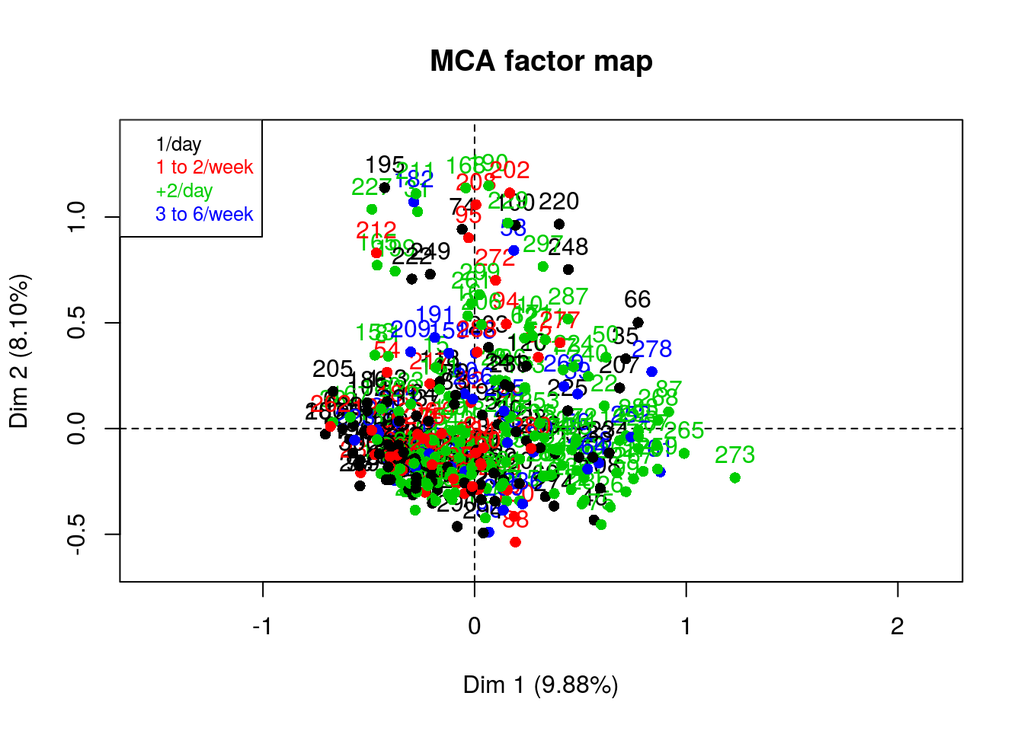

```r
plot(mca, invisible = c("var","quali.sup"),habillage="frequency")
```